# Risk Factor Analysis

## Outcome Variable

**Outcome Variable:** haz

## Predictor Variables

**Intervention Variable:** impsan

**Adjustment Set:**

- arm
- sex
- W_mage
- meducyrs
- feducyrs
- hhwealth_quart
- hfoodsec
- W_mhtcm
- W_nrooms
- W_nchldlt5
- W_parity
- impfloor
- safeh20
- delta_W_mage
- delta_meducyrs
- delta_feducyrs
- delta_hhwealth_quart
- delta_hfoodsec
- delta_W_mhtcm
- delta_W_nrooms
- delta_W_nchldlt5
- delta_W_parity
- delta_impfloor
- delta_safeh20

## Stratifying Variables

The analysis was stratified on these variable(s):

- agecat
- studyid
- country

## Data Summary

| agecat | studyid | country | impsan | n_cell | n |
| --- | --- | --- | --- | --- | --- |
| Birth | ki0047075b-MAL-ED | BANGLADESH | 1 | 197 | 234 |
| Birth | ki0047075b-MAL-ED | BANGLADESH | 0 | 37 | 234 |
| Birth | ki0047075b-MAL-ED | BRAZIL | 1 | 170 | 174 |
| Birth | ki0047075b-MAL-ED | BRAZIL | 0 | 4 | 174 |
| Birth | ki0047075b-MAL-ED | INDIA | 1 | 92 | 190 |
| Birth | ki0047075b-MAL-ED | INDIA | 0 | 98 | 190 |
| Birth | ki0047075b-MAL-ED | NEPAL | 1 | 170 | 171 |
| Birth | ki0047075b-MAL-ED | NEPAL | 0 | 1 | 171 |
| Birth | ki0047075b-MAL-ED | PERU | 1 | 62 | 250 |
| Birth | ki0047075b-MAL-ED | PERU | 0 | 188 | 250 |
| Birth | ki0047075b-MAL-ED | SOUTH AFRICA | 1 | 2 | 213 |
| Birth | ki0047075b-MAL-ED | SOUTH AFRICA | 0 | 211 | 213 |
| Birth | ki0047075b-MAL-ED | TANZANIA, UNITED REPUBLIC OF | 1 | 0 | 113 |
| Birth | ki0047075b-MAL-ED | TANZANIA, UNITED REPUBLIC OF | 0 | 113 | 113 |
| Birth | ki1017093-NIH-Birth | BANGLADESH | 1 | 9 | 28 |
| Birth | ki1017093-NIH-Birth | BANGLADESH | 0 | 19 | 28 |
| Birth | ki1017093c-NIH-Crypto | BANGLADESH | 1 | 25 | 27 |
| Birth | ki1017093c-NIH-Crypto | BANGLADESH | 0 | 2 | 27 |
| Birth | ki1114097-CONTENT | PERU | 1 | 1 | 2 |
| Birth | ki1114097-CONTENT | PERU | 0 | 1 | 2 |
| Birth | ki1135781-COHORTS | GUATEMALA | 1 | 45 | 491 |
| Birth | ki1135781-COHORTS | GUATEMALA | 0 | 446 | 491 |
| Birth | ki1135781-COHORTS | INDIA | 1 | 1767 | 4776 |
| Birth | ki1135781-COHORTS | INDIA | 0 | 3009 | 4776 |
| Birth | ki1135781-COHORTS | PHILIPPINES | 1 | 178 | 1191 |
| Birth | ki1135781-COHORTS | PHILIPPINES | 0 | 1013 | 1191 |
| Birth | kiGH5241-JiVitA-3 | BANGLADESH | 1 | 13187 | 19592 |
| Birth | kiGH5241-JiVitA-3 | BANGLADESH | 0 | 6405 | 19592 |
| Birth | kiGH5241-JiVitA-4 | BANGLADESH | 1 | 606 | 822 |
| Birth | kiGH5241-JiVitA-4 | BANGLADESH | 0 | 216 | 822 |

[output cut: 68 more lines]

The following strata were considered:

- agecat: 24 months, studyid: ki0047075b-MAL-ED, country: BANGLADESH
- agecat: 24 months, studyid: ki0047075b-MAL-ED, country: BRAZIL
- agecat: 24 months, studyid: ki0047075b-MAL-ED, country: INDIA
- agecat: 24 months, studyid: ki0047075b-MAL-ED, country: NEPAL
- agecat: 24 months, studyid: ki0047075b-MAL-ED, country: PERU
- agecat: 24 months, studyid: ki0047075b-MAL-ED, country: SOUTH AFRICA
- agecat: 24 months, studyid: ki0047075b-MAL-ED, country: TANZANIA, UNITED REPUBLIC OF
- agecat: 24 months, studyid: ki1017093-NIH-Birth, country: BANGLADESH
- agecat: 24 months, studyid: ki1017093b-PROVIDE, country: BANGLADESH
- agecat: 24 months, studyid: ki1017093c-NIH-Crypto, country: BANGLADESH
- agecat: 24 months, studyid: ki1114097-CONTENT, country: PERU
- agecat: 24 months, studyid: ki1135781-COHORTS, country: GUATEMALA
- agecat: 24 months, studyid: ki1135781-COHORTS, country: INDIA
- agecat: 24 months, studyid: ki1135781-COHORTS, country: PHILIPPINES
- agecat: 24 months, studyid: ki1148112-LCNI-5, country: MALAWI
- agecat: 24 months, studyid: kiGH5241-JiVitA-3, country: BANGLADESH
- agecat: 24 months, studyid: kiGH5241-JiVitA-4, country: BANGLADESH
- agecat: 6 months, studyid: ki0047075b-MAL-ED, country: BANGLADESH
- agecat: 6 months, studyid: ki0047075b-MAL-ED, country: BRAZIL
- agecat: 6 months, studyid: ki0047075b-MAL-ED, country: INDIA
- agecat: 6 months, studyid: ki0047075b-MAL-ED, country: NEPAL
- agecat: 6 months, studyid: ki0047075b-MAL-ED, country: PERU
- agecat: 6 months, studyid: ki0047075b-MAL-ED, country: SOUTH AFRICA
- agecat: 6 months, studyid: ki0047075b-MAL-ED, country: TANZANIA, UNITED REPUBLIC OF
- agecat: 6 months, studyid: ki1017093-NIH-Birth, country: BANGLADESH
- agecat: 6 months, studyid: ki1017093b-PROVIDE, country: BANGLADESH
- agecat: 6 months, studyid: ki1017093c-NIH-Crypto, country: BANGLADESH
- agecat: 6 months, studyid: ki1114097-CONTENT, country: PERU
- agecat: 6 months, studyid: ki1135781-COHORTS, country: GUATEMALA
- agecat: 6 months, studyid: ki1135781-COHORTS, country: INDIA
- agecat: 6 months, studyid: ki1135781-COHORTS, country: PHILIPPINES
- agecat: 6 months, studyid: ki1148112-LCNI-5, country: MALAWI
- agecat: 6 months, studyid: kiGH5241-JiVitA-3, country: BANGLADESH
- agecat: 6 months, studyid: kiGH5241-JiVitA-4, country: BANGLADESH
- agecat: Birth, studyid: ki0047075b-MAL-ED, country: BANGLADESH
- agecat: Birth, studyid: ki0047075b-MAL-ED, country: BRAZIL
- agecat: Birth, studyid: ki0047075b-MAL-ED, country: INDIA
- agecat: Birth, studyid: ki0047075b-MAL-ED, country: NEPAL
- agecat: Birth, studyid: ki0047075b-MAL-ED, country: PERU
- agecat: Birth, studyid: ki0047075b-MAL-ED, country: SOUTH AFRICA
- agecat: Birth, studyid: ki0047075b-MAL-ED, country: TANZANIA, UNITED REPUBLIC OF
- agecat: Birth, studyid: ki1017093-NIH-Birth, country: BANGLADESH
- agecat: Birth, studyid: ki1017093c-NIH-Crypto, country: BANGLADESH
- agecat: Birth, studyid: ki1114097-CONTENT, country: PERU
- agecat: Birth, studyid: ki1135781-COHORTS, country: GUATEMALA
- agecat: Birth, studyid: ki1135781-COHORTS, country: INDIA
- agecat: Birth, studyid: ki1135781-COHORTS, country: PHILIPPINES
- agecat: Birth, studyid: kiGH5241-JiVitA-3, country: BANGLADESH
- agecat: Birth, studyid: kiGH5241-JiVitA-4, country: BANGLADESH

### Dropped Strata

Some strata were dropped due to rare outcomes:

- agecat: Birth, studyid: ki0047075b-MAL-ED, country: BRAZIL
- agecat: Birth, studyid: ki0047075b-MAL-ED, country: NEPAL
- agecat: Birth, studyid: ki0047075b-MAL-ED, country: SOUTH AFRICA
- agecat: Birth, studyid: ki0047075b-MAL-ED, country: TANZANIA, UNITED REPUBLIC OF
- agecat: Birth, studyid: ki1017093c-NIH-Crypto, country: BANGLADESH
- agecat: Birth, studyid: ki1114097-CONTENT, country: PERU
- agecat: 6 months, studyid: ki0047075b-MAL-ED, country: BRAZIL
- agecat: 6 months, studyid: ki0047075b-MAL-ED, country: NEPAL
- agecat: 6 months, studyid: ki0047075b-MAL-ED, country: SOUTH AFRICA
- agecat: 6 months, studyid: ki0047075b-MAL-ED, country: TANZANIA, UNITED REPUBLIC OF
- agecat: 6 months, studyid: ki1148112-LCNI-5, country: MALAWI
- agecat: 24 months, studyid: ki0047075b-MAL-ED, country: BRAZIL
- agecat: 24 months, studyid: ki0047075b-MAL-ED, country: NEPAL
- agecat: 24 months, studyid: ki0047075b-MAL-ED, country: SOUTH AFRICA
- agecat: 24 months, studyid: ki0047075b-MAL-ED, country: TANZANIA, UNITED REPUBLIC OF
- agecat: 24 months, studyid: ki1148112-LCNI-5, country: MALAWI

## Methods Detail

We’re interested in the causal parameters $E[Y_a]$ for all values of $a \in \mathcal{A}$. These parameters represent the mean outcome if, possibly contrary to fact, we intervened to set all units to have $A=a$. Under the randomization and positivity assumptions, these are identified by the statistical parameters $\psi_a=E_W[E_{Y|A,W}(Y|A=a,W)]$. In addition, we’re interested in the mean of $Y$, $E[Y]$ under no intervention (the observed mean). We will estimate these parameters by using SuperLearner to fit the relevant likelihood factors – $E_{Y|A,W}(Y|A=a,W)$ and $p(A=a|W)$, and then updating our likelihood fit using a joint TMLE.

For unadjusted analyses ($W=\{\}$), initial likelihoods were estimated using Lrnr_glm to estimate the simple $E(Y|A)$ and Lrnr_mean to estimate $p(A)$. For adjusted analyses, a small library containing Lrnr_glmnet, Lrnr_xgboost, and Lrnr_mean was used.

Having estimated these parameters, we will then use the delta method to estimate relative risks and attributable risks relative to a prespecified baseline level of $A$.

# Results Detail

## Results Plots

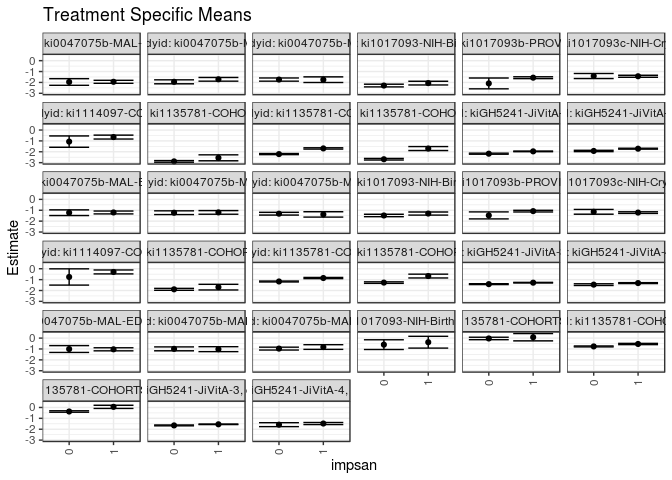

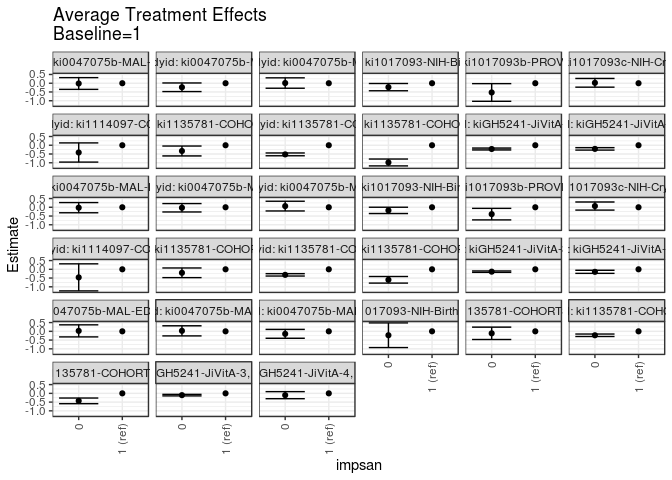

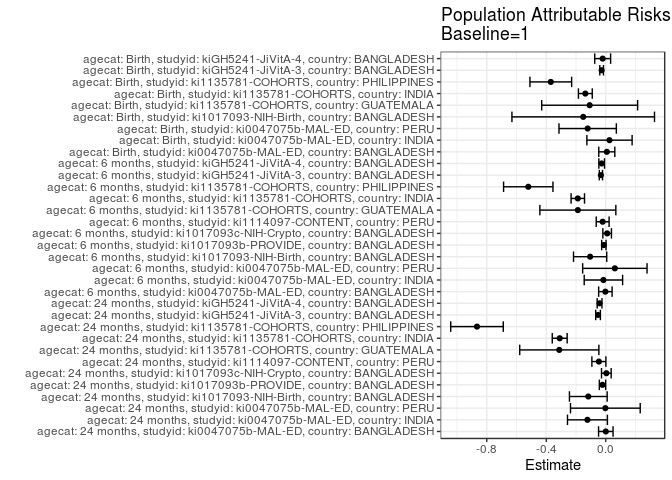

## Results Table

### Parameter: TSM

| agecat | studyid | country | intervention_level | baseline_level | estimate | ci_lower | ci_upper |
| --- | --- | --- | --- | --- | --- | --- | --- |
| Birth | ki0047075b-MAL-ED | BANGLADESH | 1 | NA | -1.0299671 | -1.1707562 | -0.8891780 |
| Birth | ki0047075b-MAL-ED | BANGLADESH | 0 | NA | -1.0038835 | -1.3184283 | -0.6893387 |
| Birth | ki0047075b-MAL-ED | INDIA | 1 | NA | -1.0164182 | -1.2434553 | -0.7893811 |
| Birth | ki0047075b-MAL-ED | INDIA | 0 | NA | -0.9884281 | -1.1669490 | -0.8099072 |
| Birth | ki0047075b-MAL-ED | PERU | 1 | NA | -0.8213870 | -1.0362595 | -0.6065145 |
| Birth | ki0047075b-MAL-ED | PERU | 0 | NA | -0.9649936 | -1.0973335 | -0.8326537 |
| Birth | ki1017093-NIH-Birth | BANGLADESH | 1 | NA | -0.3777778 | -0.9207364 | 0.1651808 |
| Birth | ki1017093-NIH-Birth | BANGLADESH | 0 | NA | -0.6010526 | -1.0492335 | -0.1528718 |
| Birth | ki1135781-COHORTS | GUATEMALA | 1 | NA | 0.0807244 | -0.2544303 | 0.4158792 |
| Birth | ki1135781-COHORTS | GUATEMALA | 0 | NA | -0.0335373 | -0.1472695 | 0.0801950 |
| Birth | ki1135781-COHORTS | INDIA | 1 | NA | -0.5404694 | -0.5971384 | -0.4838003 |
| Birth | ki1135781-COHORTS | INDIA | 0 | NA | -0.7658010 | -0.8088284 | -0.7227735 |
| Birth | ki1135781-COHORTS | PHILIPPINES | 1 | NA | 0.0558345 | -0.0909834 | 0.2026524 |
| Birth | ki1135781-COHORTS | PHILIPPINES | 0 | NA | -0.3719253 | -0.4404940 | -0.3033566 |
| Birth | kiGH5241-JiVitA-3 | BANGLADESH | 1 | NA | -1.5475208 | -1.5710698 | -1.5239717 |
| Birth | kiGH5241-JiVitA-3 | BANGLADESH | 0 | NA | -1.6501731 | -1.6885598 | -1.6117864 |
| Birth | kiGH5241-JiVitA-4 | BANGLADESH | 1 | NA | -1.4769784 | -1.5707254 | -1.3832314 |
| Birth | kiGH5241-JiVitA-4 | BANGLADESH | 0 | NA | -1.5809246 | -1.7613489 | -1.4005003 |
| 6 months | ki0047075b-MAL-ED | BANGLADESH | 1 | NA | -1.2008632 | -1.3324330 | -1.0692934 |
| 6 months | ki0047075b-MAL-ED | BANGLADESH | 0 | NA | -1.2241085 | -1.4839810 | -0.9642361 |
| 6 months | ki0047075b-MAL-ED | INDIA | 1 | NA | -1.1979750 | -1.3649297 | -1.0310202 |
| 6 months | ki0047075b-MAL-ED | INDIA | 0 | NA | -1.2250705 | -1.3970430 | -1.0530980 |
| 6 months | ki0047075b-MAL-ED | PERU | 1 | NA | -1.3822310 | -1.6292028 | -1.1352592 |
| 6 months | ki0047075b-MAL-ED | PERU | 0 | NA | -1.3156786 | -1.4415254 | -1.1898318 |
| 6 months | ki1017093-NIH-Birth | BANGLADESH | 1 | NA | -1.3023313 | -1.4445017 | -1.1601609 |
| 6 months | ki1017093-NIH-Birth | BANGLADESH | 0 | NA | -1.4800675 | -1.5921007 | -1.3680342 |
| 6 months | ki1017093b-PROVIDE | BANGLADESH | 1 | NA | -1.0798506 | -1.1577315 | -1.0019697 |
| 6 months | ki1017093b-PROVIDE | BANGLADESH | 0 | NA | -1.4714317 | -1.7929343 | -1.1499292 |
| 6 months | ki1017093c-NIH-Crypto | BANGLADESH | 1 | NA | -1.2125504 | -1.2885242 | -1.1365766 |
| 6 months | ki1017093c-NIH-Crypto | BANGLADESH | 0 | NA | -1.1433629 | -1.3624265 | -0.9242992 |
| 6 months | ki1114097-CONTENT | PERU | 1 | NA | -0.2931515 | -0.4730311 | -0.1132718 |
| 6 months | ki1114097-CONTENT | PERU | 0 | NA | -0.7552630 | -1.5039875 | -0.0065385 |
| 6 months | ki1135781-COHORTS | GUATEMALA | 1 | NA | -1.6913289 | -1.9528498 | -1.4298079 |
| 6 months | ki1135781-COHORTS | GUATEMALA | 0 | NA | -1.8917434 | -1.9798428 | -1.8036440 |
| 6 months | ki1135781-COHORTS | INDIA | 1 | NA | -0.8535472 | -0.9080711 | -0.7990232 |
| 6 months | ki1135781-COHORTS | INDIA | 0 | NA | -1.1709248 | -1.2126036 | -1.1292460 |
| 6 months | ki1135781-COHORTS | PHILIPPINES | 1 | NA | -0.6733031 | -0.8486050 | -0.4980011 |
| 6 months | ki1135781-COHORTS | PHILIPPINES | 0 | NA | -1.2728231 | -1.3432277 | -1.2024185 |
| 6 months | kiGH5241-JiVitA-3 | BANGLADESH | 1 | NA | -1.2809696 | -1.3065701 | -1.2553691 |
| 6 months | kiGH5241-JiVitA-3 | BANGLADESH | 0 | NA | -1.4157169 | -1.4548659 | -1.3765679 |
| 6 months | kiGH5241-JiVitA-4 | BANGLADESH | 1 | NA | -1.3167808 | -1.3586495 | -1.2749121 |
| 6 months | kiGH5241-JiVitA-4 | BANGLADESH | 0 | NA | -1.4609390 | -1.5411855 | -1.3806925 |
| 24 months | ki0047075b-MAL-ED | BANGLADESH | 1 | NA | -1.9435697 | -2.0822465 | -1.8048929 |
| 24 months | ki0047075b-MAL-ED | BANGLADESH | 0 | NA | -1.9587800 | -2.2628896 | -1.6546705 |
| 24 months | ki0047075b-MAL-ED | INDIA | 1 | NA | -1.7141534 | -1.8841020 | -1.5442047 |
| 24 months | ki0047075b-MAL-ED | INDIA | 0 | NA | -1.9444935 | -2.1260318 | -1.7629552 |
| 24 months | ki0047075b-MAL-ED | PERU | 1 | NA | -1.7488101 | -2.0089534 | -1.4886667 |
| 24 months | ki0047075b-MAL-ED | PERU | 0 | NA | -1.7378240 | -1.8835679 | -1.5920801 |
| 24 months | ki1017093-NIH-Birth | BANGLADESH | 1 | NA | -2.0635139 | -2.2332239 | -1.8938040 |
| 24 months | ki1017093-NIH-Birth | BANGLADESH | 0 | NA | -2.2873491 | -2.4120801 | -2.1626180 |
| 24 months | ki1017093b-PROVIDE | BANGLADESH | 1 | NA | -1.5635960 | -1.6478614 | -1.4793306 |
| 24 months | ki1017093b-PROVIDE | BANGLADESH | 0 | NA | -2.0912291 | -2.5895219 | -1.5929364 |
| 24 months | ki1017093c-NIH-Crypto | BANGLADESH | 1 | NA | -1.4337009 | -1.5253327 | -1.3420691 |
| 24 months | ki1017093c-NIH-Crypto | BANGLADESH | 0 | NA | -1.4104557 | -1.6425018 | -1.1784096 |
| 24 months | ki1114097-CONTENT | PERU | 1 | NA | -0.6500808 | -0.8295196 | -0.4706419 |
| 24 months | ki1114097-CONTENT | PERU | 0 | NA | -1.0640607 | -1.5852929 | -0.5428285 |
| 24 months | ki1135781-COHORTS | GUATEMALA | 1 | NA | -2.5551344 | -2.8284766 | -2.2817922 |
| 24 months | ki1135781-COHORTS | GUATEMALA | 0 | NA | -2.8825256 | -2.9566238 | -2.8084275 |
| 24 months | ki1135781-COHORTS | INDIA | 1 | NA | -1.6907976 | -1.7520760 | -1.6295192 |
| 24 months | ki1135781-COHORTS | INDIA | 0 | NA | -2.2128732 | -2.2637649 | -2.1619815 |
| 24 months | ki1135781-COHORTS | PHILIPPINES | 1 | NA | -1.7023822 | -1.8846095 | -1.5201549 |
| 24 months | ki1135781-COHORTS | PHILIPPINES | 0 | NA | -2.6858012 | -2.7576166 | -2.6139859 |
| 24 months | kiGH5241-JiVitA-3 | BANGLADESH | 1 | NA | -1.9608877 | -1.9927130 | -1.9290623 |
| 24 months | kiGH5241-JiVitA-3 | BANGLADESH | 0 | NA | -2.1754148 | -2.2245188 | -2.1263108 |
| 24 months | kiGH5241-JiVitA-4 | BANGLADESH | 1 | NA | -1.7163525 | -1.7570320 | -1.6756730 |
| 24 months | kiGH5241-JiVitA-4 | BANGLADESH | 0 | NA | -1.9241176 | -1.9836041 | -1.8646312 |

### Parameter: E(Y)

| agecat | studyid | country | intervention_level | baseline_level | estimate | ci_lower | ci_upper |
| --- | --- | --- | --- | --- | --- | --- | --- |
| Birth | ki0047075b-MAL-ED | BANGLADESH | NA | NA | -1.0229487 | -1.1509575 | -0.8949400 |
| Birth | ki0047075b-MAL-ED | INDIA | NA | NA | -0.9912632 | -1.1342711 | -0.8482552 |
| Birth | ki0047075b-MAL-ED | PERU | NA | NA | -0.9430000 | -1.0581275 | -0.8278725 |
| Birth | ki1017093-NIH-Birth | BANGLADESH | NA | NA | -0.5292857 | -0.8821252 | -0.1764462 |
| Birth | ki1135781-COHORTS | GUATEMALA | NA | NA | -0.0275356 | -0.1359303 | 0.0808590 |
| Birth | ki1135781-COHORTS | INDIA | NA | NA | -0.6777115 | -0.7106054 | -0.6448175 |
| Birth | ki1135781-COHORTS | PHILIPPINES | NA | NA | -0.3137364 | -0.3764483 | -0.2510244 |
| Birth | kiGH5241-JiVitA-3 | BANGLADESH | NA | NA | -1.5751797 | -1.5949356 | -1.5554237 |
| Birth | kiGH5241-JiVitA-4 | BANGLADESH | NA | NA | -1.4976642 | -1.5817349 | -1.4135935 |
| 6 months | ki0047075b-MAL-ED | BANGLADESH | NA | NA | -1.2033681 | -1.3212429 | -1.0854932 |
| 6 months | ki0047075b-MAL-ED | INDIA | NA | NA | -1.2137196 | -1.3330761 | -1.0943631 |
| 6 months | ki0047075b-MAL-ED | PERU | NA | NA | -1.3210330 | -1.4311040 | -1.2109619 |
| 6 months | ki1017093-NIH-Birth | BANGLADESH | NA | NA | -1.4073821 | -1.4960598 | -1.3187043 |
| 6 months | ki1017093b-PROVIDE | BANGLADESH | NA | NA | -1.0925674 | -1.1686395 | -1.0164954 |
| 6 months | ki1017093c-NIH-Crypto | BANGLADESH | NA | NA | -1.2031037 | -1.2749632 | -1.1312442 |
| 6 months | ki1114097-CONTENT | PERU | NA | NA | -0.3139217 | -0.4868486 | -0.1409948 |
| 6 months | ki1135781-COHORTS | GUATEMALA | NA | NA | -1.8789210 | -1.9609921 | -1.7968498 |
| 6 months | ki1135781-COHORTS | INDIA | NA | NA | -1.0414424 | -1.0741113 | -1.0087734 |
| 6 months | ki1135781-COHORTS | PHILIPPINES | NA | NA | -1.1942936 | -1.2608624 | -1.1277248 |
| 6 months | kiGH5241-JiVitA-3 | BANGLADESH | NA | NA | -1.3134804 | -1.3366079 | -1.2903528 |
| 6 months | kiGH5241-JiVitA-4 | BANGLADESH | NA | NA | -1.3440477 | -1.3813060 | -1.3067894 |
| 24 months | ki0047075b-MAL-ED | BANGLADESH | NA | NA | -1.9431132 | -2.0691678 | -1.8170586 |
| 24 months | ki0047075b-MAL-ED | INDIA | NA | NA | -1.8372222 | -1.9638017 | -1.7106427 |
| 24 months | ki0047075b-MAL-ED | PERU | NA | NA | -1.7514286 | -1.8732727 | -1.6295845 |
| 24 months | ki1017093-NIH-Birth | BANGLADESH | NA | NA | -2.1807945 | -2.2835902 | -2.0779987 |
| 24 months | ki1017093b-PROVIDE | BANGLADESH | NA | NA | -1.5853993 | -1.6687810 | -1.5020176 |
| 24 months | ki1017093c-NIH-Crypto | BANGLADESH | NA | NA | -1.4297217 | -1.5139732 | -1.3454701 |
| 24 months | ki1114097-CONTENT | PERU | NA | NA | -0.6962195 | -0.8674103 | -0.5250287 |
| 24 months | ki1135781-COHORTS | GUATEMALA | NA | NA | -2.8674777 | -2.9383136 | -2.7966417 |
| 24 months | ki1135781-COHORTS | INDIA | NA | NA | -2.0003783 | -2.0396528 | -1.9611037 |
| 24 months | ki1135781-COHORTS | PHILIPPINES | NA | NA | -2.5681010 | -2.6370882 | -2.4991138 |
| 24 months | kiGH5241-JiVitA-3 | BANGLADESH | NA | NA | -2.0126943 | -2.0403978 | -1.9849907 |
| 24 months | kiGH5241-JiVitA-4 | BANGLADESH | NA | NA | -1.7578934 | -1.7933205 | -1.7224663 |

### Parameter: ATE

| agecat | studyid | country | intervention_level | baseline_level | estimate | ci_lower | ci_upper |
| --- | --- | --- | --- | --- | --- | --- | --- |
| Birth | ki0047075b-MAL-ED | BANGLADESH | 1 | 1 | 0.0000000 | 0.0000000 | 0.0000000 |
| Birth | ki0047075b-MAL-ED | BANGLADESH | 0 | 1 | 0.0260836 | -0.3189214 | 0.3710886 |
| Birth | ki0047075b-MAL-ED | INDIA | 1 | 1 | 0.0000000 | 0.0000000 | 0.0000000 |
| Birth | ki0047075b-MAL-ED | INDIA | 0 | 1 | 0.0279900 | -0.2603374 | 0.3163175 |
| Birth | ki0047075b-MAL-ED | PERU | 1 | 1 | 0.0000000 | 0.0000000 | 0.0000000 |
| Birth | ki0047075b-MAL-ED | PERU | 0 | 1 | -0.1436066 | -0.3970226 | 0.1098094 |
| Birth | ki1017093-NIH-Birth | BANGLADESH | 1 | 1 | 0.0000000 | 0.0000000 | 0.0000000 |
| Birth | ki1017093-NIH-Birth | BANGLADESH | 0 | 1 | -0.2232749 | -0.9273133 | 0.4807636 |
| Birth | ki1135781-COHORTS | GUATEMALA | 1 | 1 | 0.0000000 | 0.0000000 | 0.0000000 |
| Birth | ki1135781-COHORTS | GUATEMALA | 0 | 1 | -0.1142617 | -0.4683378 | 0.2398144 |
| Birth | ki1135781-COHORTS | INDIA | 1 | 1 | 0.0000000 | 0.0000000 | 0.0000000 |
| Birth | ki1135781-COHORTS | INDIA | 0 | 1 | -0.2253316 | -0.2961997 | -0.1544634 |
| Birth | ki1135781-COHORTS | PHILIPPINES | 1 | 1 | 0.0000000 | 0.0000000 | 0.0000000 |
| Birth | ki1135781-COHORTS | PHILIPPINES | 0 | 1 | -0.4277598 | -0.5891982 | -0.2663215 |
| Birth | kiGH5241-JiVitA-3 | BANGLADESH | 1 | 1 | 0.0000000 | 0.0000000 | 0.0000000 |
| Birth | kiGH5241-JiVitA-3 | BANGLADESH | 0 | 1 | -0.1026523 | -0.1451571 | -0.0601476 |
| Birth | kiGH5241-JiVitA-4 | BANGLADESH | 1 | 1 | 0.0000000 | 0.0000000 | 0.0000000 |
| Birth | kiGH5241-JiVitA-4 | BANGLADESH | 0 | 1 | -0.1039462 | -0.3065680 | 0.0986757 |
| 6 months | ki0047075b-MAL-ED | BANGLADESH | 1 | 1 | 0.0000000 | 0.0000000 | 0.0000000 |
| 6 months | ki0047075b-MAL-ED | BANGLADESH | 0 | 1 | -0.0232453 | -0.3145152 | 0.2680245 |
| 6 months | ki0047075b-MAL-ED | INDIA | 1 | 1 | 0.0000000 | 0.0000000 | 0.0000000 |
| 6 months | ki0047075b-MAL-ED | INDIA | 0 | 1 | -0.0270956 | -0.2672199 | 0.2130287 |
| 6 months | ki0047075b-MAL-ED | PERU | 1 | 1 | 0.0000000 | 0.0000000 | 0.0000000 |
| 6 months | ki0047075b-MAL-ED | PERU | 0 | 1 | 0.0665524 | -0.2119890 | 0.3450938 |
| 6 months | ki1017093-NIH-Birth | BANGLADESH | 1 | 1 | 0.0000000 | 0.0000000 | 0.0000000 |
| 6 months | ki1017093-NIH-Birth | BANGLADESH | 0 | 1 | -0.1777361 | -0.3575283 | 0.0020560 |
| 6 months | ki1017093b-PROVIDE | BANGLADESH | 1 | 1 | 0.0000000 | 0.0000000 | 0.0000000 |
| 6 months | ki1017093b-PROVIDE | BANGLADESH | 0 | 1 | -0.3915812 | -0.7205052 | -0.0626572 |
| 6 months | ki1017093c-NIH-Crypto | BANGLADESH | 1 | 1 | 0.0000000 | 0.0000000 | 0.0000000 |
| 6 months | ki1017093c-NIH-Crypto | BANGLADESH | 0 | 1 | 0.0691875 | -0.1626998 | 0.3010749 |
| 6 months | ki1114097-CONTENT | PERU | 1 | 1 | 0.0000000 | 0.0000000 | 0.0000000 |
| 6 months | ki1114097-CONTENT | PERU | 0 | 1 | -0.4621116 | -1.2352510 | 0.3110278 |
| 6 months | ki1135781-COHORTS | GUATEMALA | 1 | 1 | 0.0000000 | 0.0000000 | 0.0000000 |
| 6 months | ki1135781-COHORTS | GUATEMALA | 0 | 1 | -0.2004145 | -0.4765966 | 0.0757675 |
| 6 months | ki1135781-COHORTS | INDIA | 1 | 1 | 0.0000000 | 0.0000000 | 0.0000000 |
| 6 months | ki1135781-COHORTS | INDIA | 0 | 1 | -0.3173777 | -0.3852980 | -0.2494573 |
| 6 months | ki1135781-COHORTS | PHILIPPINES | 1 | 1 | 0.0000000 | 0.0000000 | 0.0000000 |
| 6 months | ki1135781-COHORTS | PHILIPPINES | 0 | 1 | -0.5995200 | -0.7886620 | -0.4103781 |
| 6 months | kiGH5241-JiVitA-3 | BANGLADESH | 1 | 1 | 0.0000000 | 0.0000000 | 0.0000000 |
| 6 months | kiGH5241-JiVitA-3 | BANGLADESH | 0 | 1 | -0.1347473 | -0.1752259 | -0.0942688 |
| 6 months | kiGH5241-JiVitA-4 | BANGLADESH | 1 | 1 | 0.0000000 | 0.0000000 | 0.0000000 |
| 6 months | kiGH5241-JiVitA-4 | BANGLADESH | 0 | 1 | -0.1441582 | -0.2336054 | -0.0547110 |
| 24 months | ki0047075b-MAL-ED | BANGLADESH | 1 | 1 | 0.0000000 | 0.0000000 | 0.0000000 |
| 24 months | ki0047075b-MAL-ED | BANGLADESH | 0 | 1 | -0.0152103 | -0.3501953 | 0.3197746 |
| 24 months | ki0047075b-MAL-ED | INDIA | 1 | 1 | 0.0000000 | 0.0000000 | 0.0000000 |
| 24 months | ki0047075b-MAL-ED | INDIA | 0 | 1 | -0.2303401 | -0.4763639 | 0.0156837 |
| 24 months | ki0047075b-MAL-ED | PERU | 1 | 1 | 0.0000000 | 0.0000000 | 0.0000000 |
| 24 months | ki0047075b-MAL-ED | PERU | 0 | 1 | 0.0109861 | -0.2858464 | 0.3078185 |
| 24 months | ki1017093-NIH-Birth | BANGLADESH | 1 | 1 | 0.0000000 | 0.0000000 | 0.0000000 |
| 24 months | ki1017093-NIH-Birth | BANGLADESH | 0 | 1 | -0.2238351 | -0.4322270 | -0.0154433 |
| 24 months | ki1017093b-PROVIDE | BANGLADESH | 1 | 1 | 0.0000000 | 0.0000000 | 0.0000000 |
| 24 months | ki1017093b-PROVIDE | BANGLADESH | 0 | 1 | -0.5276331 | -1.0330188 | -0.0222474 |
| 24 months | ki1017093c-NIH-Crypto | BANGLADESH | 1 | 1 | 0.0000000 | 0.0000000 | 0.0000000 |
| 24 months | ki1017093c-NIH-Crypto | BANGLADESH | 0 | 1 | 0.0232452 | -0.2259344 | 0.2724248 |
| 24 months | ki1114097-CONTENT | PERU | 1 | 1 | 0.0000000 | 0.0000000 | 0.0000000 |
| 24 months | ki1114097-CONTENT | PERU | 0 | 1 | -0.4139799 | -0.9630232 | 0.1350633 |
| 24 months | ki1135781-COHORTS | GUATEMALA | 1 | 1 | 0.0000000 | 0.0000000 | 0.0000000 |
| 24 months | ki1135781-COHORTS | GUATEMALA | 0 | 1 | -0.3273912 | -0.6106900 | -0.0440925 |
| 24 months | ki1135781-COHORTS | INDIA | 1 | 1 | 0.0000000 | 0.0000000 | 0.0000000 |
| 24 months | ki1135781-COHORTS | INDIA | 0 | 1 | -0.5220756 | -0.6018651 | -0.4422861 |
| 24 months | ki1135781-COHORTS | PHILIPPINES | 1 | 1 | 0.0000000 | 0.0000000 | 0.0000000 |
| 24 months | ki1135781-COHORTS | PHILIPPINES | 0 | 1 | -0.9834190 | -1.1795762 | -0.7872619 |
| 24 months | kiGH5241-JiVitA-3 | BANGLADESH | 1 | 1 | 0.0000000 | 0.0000000 | 0.0000000 |
| 24 months | kiGH5241-JiVitA-3 | BANGLADESH | 0 | 1 | -0.2145271 | -0.2681476 | -0.1609066 |
| 24 months | kiGH5241-JiVitA-4 | BANGLADESH | 1 | 1 | 0.0000000 | 0.0000000 | 0.0000000 |
| 24 months | kiGH5241-JiVitA-4 | BANGLADESH | 0 | 1 | -0.2077651 | -0.2775210 | -0.1380092 |

### Parameter: PAR

| agecat | studyid | country | intervention_level | baseline_level | estimate | ci_lower | ci_upper |
| --- | --- | --- | --- | --- | --- | --- | --- |
| Birth | ki0047075b-MAL-ED | BANGLADESH | 1 | NA | 0.0070184 | -0.0469788 | 0.0610156 |
| Birth | ki0047075b-MAL-ED | INDIA | 1 | NA | 0.0251550 | -0.1269239 | 0.1772340 |
| Birth | ki0047075b-MAL-ED | PERU | 1 | NA | -0.1216130 | -0.3144593 | 0.0712333 |
| Birth | ki1017093-NIH-Birth | BANGLADESH | 1 | NA | -0.1515079 | -0.6308647 | 0.3278488 |
| Birth | ki1135781-COHORTS | GUATEMALA | 1 | NA | -0.1082601 | -0.4307385 | 0.2142183 |
| Birth | ki1135781-COHORTS | INDIA | 1 | NA | -0.1372421 | -0.1837353 | -0.0907490 |
| Birth | ki1135781-COHORTS | PHILIPPINES | 1 | NA | -0.3695709 | -0.5097825 | -0.2293592 |
| Birth | kiGH5241-JiVitA-3 | BANGLADESH | 1 | NA | -0.0276589 | -0.0399970 | -0.0153208 |
| Birth | kiGH5241-JiVitA-4 | BANGLADESH | 1 | NA | -0.0206858 | -0.0740613 | 0.0326896 |
| 6 months | ki0047075b-MAL-ED | BANGLADESH | 1 | NA | -0.0025048 | -0.0476744 | 0.0426648 |
| 6 months | ki0047075b-MAL-ED | INDIA | 1 | NA | -0.0157446 | -0.1448814 | 0.1133921 |
| 6 months | ki0047075b-MAL-ED | PERU | 1 | NA | 0.0611981 | -0.1552467 | 0.2776428 |
| 6 months | ki1017093-NIH-Birth | BANGLADESH | 1 | NA | -0.1050507 | -0.2166450 | 0.0065435 |
| 6 months | ki1017093b-PROVIDE | BANGLADESH | 1 | NA | -0.0127169 | -0.0273575 | 0.0019238 |
| 6 months | ki1017093c-NIH-Crypto | BANGLADESH | 1 | NA | 0.0094467 | -0.0193830 | 0.0382764 |
| 6 months | ki1114097-CONTENT | PERU | 1 | NA | -0.0207703 | -0.0640084 | 0.0224679 |
| 6 months | ki1135781-COHORTS | GUATEMALA | 1 | NA | -0.1875921 | -0.4430582 | 0.0678740 |
| 6 months | ki1135781-COHORTS | INDIA | 1 | NA | -0.1878952 | -0.2329336 | -0.1428568 |
| 6 months | ki1135781-COHORTS | PHILIPPINES | 1 | NA | -0.5209905 | -0.6869732 | -0.3550079 |
| 6 months | kiGH5241-JiVitA-3 | BANGLADESH | 1 | NA | -0.0325108 | -0.0433374 | -0.0216841 |
| 6 months | kiGH5241-JiVitA-4 | BANGLADESH | 1 | NA | -0.0272669 | -0.0462790 | -0.0082548 |
| 24 months | ki0047075b-MAL-ED | BANGLADESH | 1 | NA | 0.0004565 | -0.0482557 | 0.0491687 |
| 24 months | ki0047075b-MAL-ED | INDIA | 1 | NA | -0.1230689 | -0.2572643 | 0.0111266 |
| 24 months | ki0047075b-MAL-ED | PERU | 1 | NA | -0.0026185 | -0.2369955 | 0.2317585 |
| 24 months | ki1017093-NIH-Birth | BANGLADESH | 1 | NA | -0.1172805 | -0.2441796 | 0.0096185 |
| 24 months | ki1017093b-PROVIDE | BANGLADESH | 1 | NA | -0.0218033 | -0.0431510 | -0.0004556 |
| 24 months | ki1017093c-NIH-Crypto | BANGLADESH | 1 | NA | 0.0039793 | -0.0284427 | 0.0364012 |
| 24 months | ki1114097-CONTENT | PERU | 1 | NA | -0.0461388 | -0.0931874 | 0.0009098 |
| 24 months | ki1135781-COHORTS | GUATEMALA | 1 | NA | -0.3123433 | -0.5784982 | -0.0461883 |
| 24 months | ki1135781-COHORTS | INDIA | 1 | NA | -0.3095807 | -0.3596896 | -0.2594717 |
| 24 months | ki1135781-COHORTS | PHILIPPINES | 1 | NA | -0.8657188 | -1.0423864 | -0.6890512 |
| 24 months | kiGH5241-JiVitA-3 | BANGLADESH | 1 | NA | -0.0518066 | -0.0674833 | -0.0361298 |
| 24 months | kiGH5241-JiVitA-4 | BANGLADESH | 1 | NA | -0.0415409 | -0.0575919 | -0.0254899 |